# **Lab-3: Customer Segmentation with Clustering Algorithms**

**Saketh Banda**

**SaiKumar Garshakurthi**

**Yasin Khan**

**Dinesh Ram Veerappan Kosal**

## **Introduction**

The below dataset has been obtained from Kaggle, to which the link is provided:

https://www.kaggle.com/datasets/gregorut/videogamesales

After obtainining the dataset we perform exploratory data analysis,then perform heirarchical clustering, DBSCAN and then k-means clustering and produce the necessary results as mentioned below in the guidelines for the assignment: Preprocess the data: Handle any missing values, normalize features if necessary, and prepare the dataset for clustering. Choose the number of clusters: Use methods such as the elbow method or silhouette analysis to determine an appropriate number of clusters (k). Apply clustering: Implement the algorithm and assign customers to clusters. Analyze the results: Examine the characteristics of each cluster and visualize your findings using relevant plots. Suggest marketing strategies: Based on cluster analysis, propose targeted marketing strategies for each group.

## **Exploratory Data Analysis (EDA)**

First, we perform exploratory data analysis (EDA) on the video game sales dataset, followed by hierarchical clustering, DBSCAN, and k-means clustering.

```
<class 'pandas.core.frame.DataFrame'>
RangeIndex: 16598 entries, 0 to 16597
Data columns (total 11 columns):
 #   Column        Non-Null Count  Dtype
---  ------        --------------  -----
 0   Rank          16598 non-null  int64
 1   Name          16598 non-null  object
 2   Platform      16598 non-null  object
 3   Year          16327 non-null  float64
 4   Genre         16598 non-null  object
 5   Publisher     16540 non-null  object
 6   NA_Sales      16598 non-null  float64
 7   EU_Sales      16598 non-null  float64
 8   JP_Sales      16598 non-null  float64
 9   Other_Sales   16598 non-null  float64
 10  Global_Sales  16598 non-null  float64
dtypes: float64(6), int64(1), object(4)
memory usage: 1.4+ MB
None

First few rows of the dataset:
   Rank                      Name Platform    Year         Genre Publisher  \
0     1                Wii Sports      Wii  2006.0        Sports  Nintendo
1     2         Super Mario Bros.      NES  1985.0      Platform  Nintendo
2     3            Mario Kart Wii      Wii  2008.0        Racing  Nintendo
3     4         Wii Sports Resort      Wii  2009.0        Sports  Nintendo
4     5  Pokemon Red/Pokemon Blue       GB  1996.0  Role-Playing  Nintendo

   NA_Sales  EU_Sales  JP_Sales  Other_Sales  Global_Sales
0     41.49     29.02      3.77         8.46         82.74
1     29.08      3.58      6.81         0.77         40.24
2     15.85     12.88      3.79         3.31         35.82
3     15.75     11.01      3.28         2.96         33.00
4     11.27      8.89     10.22         1.00         31.37

Summary statistics:
               Rank          Year      NA_Sales      EU_Sales      JP_Sales  \
count  16598.000000  16327.000000  16598.000000  16598.000000  16598.000000
mean    8300.605254   2006.406443      0.264667      0.146652      0.077782
std     4791.853933      5.828981      0.816683      0.505351      0.309291
```

[output cut: 19 more lines]

```
Platform          0
Year            271
Genre             0
Publisher        58
NA_Sales          0
EU_Sales          0
JP_Sales          0
Other_Sales       0
Global_Sales      0
dtype: int64

Unique values in categorical columns:
Platform: 31
Genre: 12
Publisher: 578
```

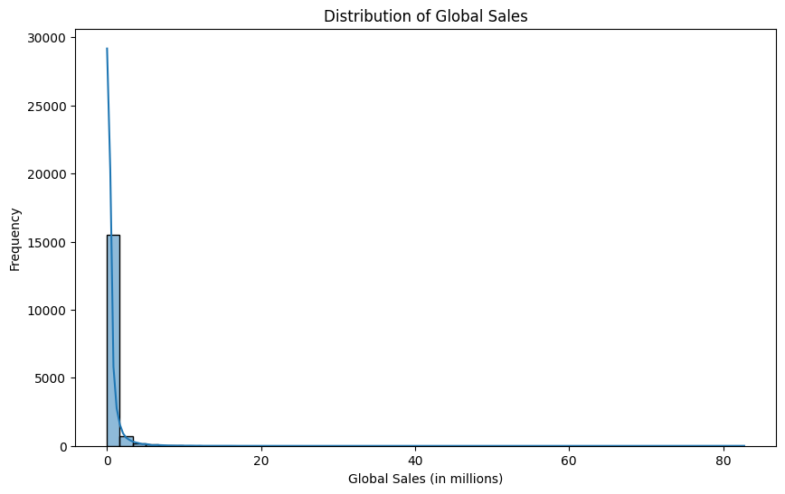

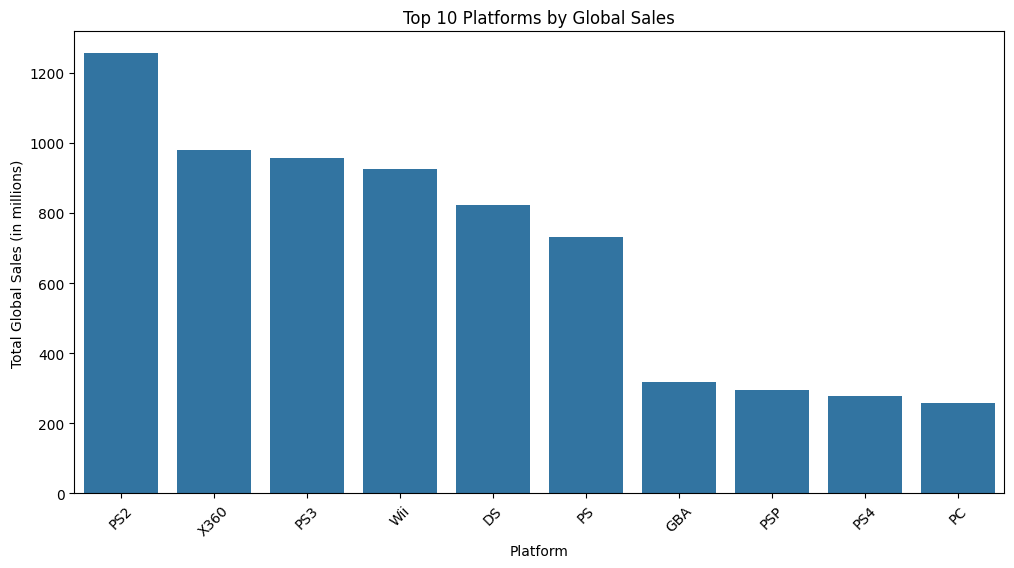

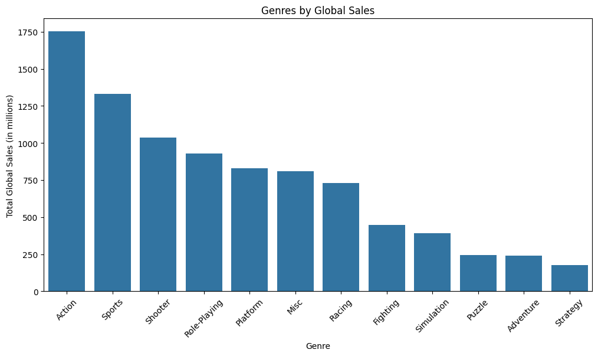

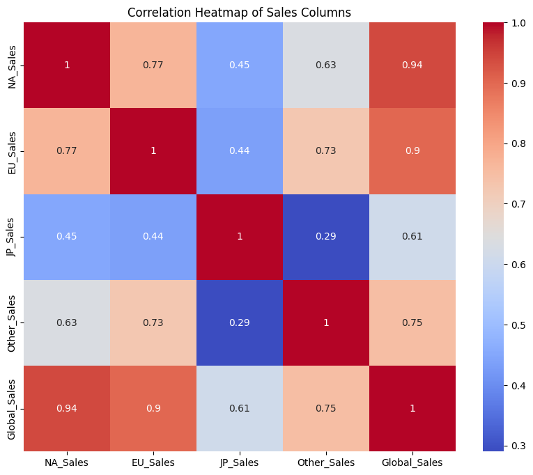

```
Exploratory Data Analysis completed.
```

```python
import pandas as pd
import numpy as np
import matplotlib.pyplot as plt
import seaborn as sns
from sklearn.preprocessing import StandardScaler
from sklearn.cluster import KMeans, DBSCAN
from sklearn.metrics import silhouette_score
from scipy.cluster.hierarchy import dendrogram, linkage
from sklearn.impute import SimpleImputer
df = pd.read_csv('C:/Users/Psycho Doc/Downloads/vgsales.csv (1)/vgsales.csv')

# Display basic information about the dataset
print(df.info())
print("\nFirst few rows of the dataset:")
print(df.head())

# Display summary statistics
print("\nSummary statistics:")
print(df.describe())

# Check for missing values
print("\nMissing values:")
print(df.isnull().sum())

# Display unique values in categorical columns
print("\nUnique values in categorical columns:")
for col in ['Platform', 'Genre', 'Publisher']:
    print(f"{col}: {df[col].nunique()}")

# Plot distribution of global sales
plt.figure(figsize=(10, 6))
sns.histplot(df['Global_Sales'], bins=50, kde=True)
plt.title('Distribution of Global Sales')
plt.xlabel('Global Sales (in millions)')
plt.ylabel('Frequency')
plt.show()

# Plot top 10 platforms by global sales
platform_sales = df.groupby('Platform')['Global_Sales'].sum().sort_values(ascending=False).head(10)
plt.figure(figsize=(12, 6))
sns.barplot(x=platform_sales.index, y=platform_sales.values)
plt.title('Top 10 Platforms by Global Sales')
plt.xlabel('Platform')
plt.ylabel('Total Global Sales (in millions)')
plt.xticks(rotation=45)
plt.show()

# Plot top 10 genres by global sales
genre_sales = df.groupby('Genre')['Global_Sales'].sum().sort_values(ascending=False)
plt.figure(figsize=(12, 6))
sns.barplot(x=genre_sales.index, y=genre_sales.values)
plt.title('Genres by Global Sales')
plt.xlabel('Genre')
plt.ylabel('Total Global Sales (in millions)')
plt.xticks(rotation=45)
plt.show()

# Correlation heatmap
sales_columns = ['NA_Sales', 'EU_Sales', 'JP_Sales', 'Other_Sales', 'Global_Sales']
correlation_matrix = df[sales_columns].corr()
plt.figure(figsize=(10, 8))
sns.heatmap(correlation_matrix, annot=True, cmap='coolwarm')
plt.title('Correlation Heatmap of Sales Columns')
plt.show()

print("Exploratory Data Analysis completed.")
```